# Single Species Gopher Model with Seasonality

Elizabeth Hiroyasu

July 18, 2016

The SSGophers.Rmd file contains a single species annual model for gopher populations. However, we expect that seasonality may be an important aspect determining gopher population growth. This model includes seasonality (summer and winter) in the matrix model presented previously.

Again, parameters and initial population sizes have been taken from literature estimates both of the growth and survival rates of the population and the densities of gopher populations for the species Thomomys bottae. For this model we used the ‘popbio’ package in R.

```r
library(popbio)
```

## Setting up the matrix

We directly filled population parameters into a 3x3 matrix, with a juvenile, subadult, and adult stage.

```r
stages = c("Juvenile", "SubAdult", "Adult")
```

The initial matrix looks as follows, for each season:

| Stage | Juvenile | SubAdult | Adult |
| --- | --- | --- | --- |
| Juvenile | 0 | f2 | f3 |
| SubAdult | p1 | 0 | 0 |
| Adult | 0 | p2 | p3 |

p1: probability of juvenile becoming a sub adult* p2: probability of a subadult becoming reproductive adult p3: probability of staying adult

f2: birth rate from subadults f3: birth rate from reproductive adults

*this term is unknown in gophers so we will use estimates from the vole population

Seasonal Matrices: Note that for now, fecundity is held constant because of the lack of differentiation in the data between subadult and adult breeding. P2 is a made up number for the winter matrix.

```r
SummerMatrix<-matrix(data=c(0,2.535, 7.775, 0.69, 0, 0, 0, 0.433, 0.777),
              nrow=3, ncol=3, byrow=TRUE,
              dimnames=list(stages,stages))

WinterMatrix<-matrix(data=c(0, 2.535, 7.775, 0.69,0,0,0, 0.33, 0.61),
                      nrow=3, ncol=3, byrow=TRUE,dimnames = list(stages, stages))
```

Taking the matrix product to create a matrix starting in summer, projecting to the following summer, we need to multiply the summer and winter matrices. We get the following, note that the % is used to denote matrix multiplication:

```
##          Juvenile SubAdult   Adult
## Juvenile  1.74915  2.56575 4.74275
## SubAdult  0.00000  1.74915 5.36475
## Adult     0.29877  0.25641 0.47397
```

The matrix product is what we will use to project the population moving forward (from summer to the following summer). Starting with the same initial vector of populations densities, we can project the population forward.

We project the population in the same way as the single species model without seasonality: To project the population to next year, we use matrix multiplication (denoted by the %*%) to multiply the transition matrix by the starting population

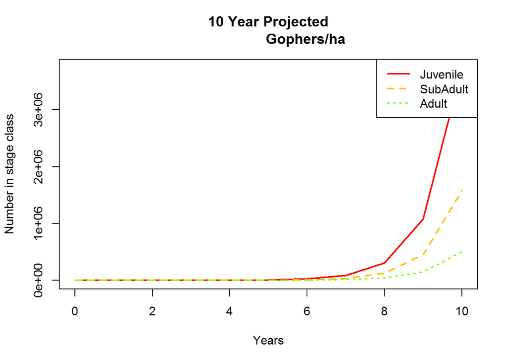

```r
N1_summer = MatrixProduct %*% N_summer

summer_projection = pop.projection(MatrixProduct, N_summer,11)
stage.vector.plot(summer_projection$stage.vectors,proportions = FALSE,
                  legend.coords="topright", main = "10 Year Projected
                  Gophers/ha")
```

## Stable stage distribution

We calculate the stable stage distribution and elasticities in the same way. It is important to note that the eigenvalues are extracted from matrix product, not the product of each matrix eigenvalue (eigenvalue(SummerMatrix%times%WinterMatrix), as opposed to eigenvalue(SummerMatrix) times eigenvalue(WinterMatrix))

```r
summer_projection$stable.stage
```

```
##   Juvenile   SubAdult      Adult
## 0.64212396 0.27079353 0.08708251
```

To determine the dominant eigenvalue, lambda, we can use the ‘lambda’ command, it is also given as part of the list of outputs from the pop.projection command. The dominany eigenvalue tells us the population growth rate of a projection matrix. If lambda is greater than one, the population will grow, if it less than one then the population will be declining, and if it is equal to one the population will be neither growing, nor declining.

```r
summer_projection$lambda
```

```
## [1] 3.474361
```

## Calculating elasticities

Finally, we can calculate the elasticities of the projection matrix. The largest value will tell us which transition contributes most to the observed population trend.

```r
elasticity(MatrixProduct)
```

```
##           Juvenile   SubAdult      Adult
## Juvenile 0.1816047 0.11233984 0.06677937
## SubAdult 0.0000000 0.17962580 0.17716739
## Adult    0.1791192 0.06482754 0.03853613
```